# Coursera Data Science Capstone, part02

Vesa Kauppinen

11 10 2020

## Capstone project

The Coursera Data Science Specialization Capstone project from Johns Hopkins University (JHU) allows students to create a usable public data product that can show their skills to potential employers. Projects are drawn from real-world problems and are conducted with industry, government, and academic partners. For this iteration of the class, JHU is partnering with SwiftKey (http://swiftkey.com/en/) to apply data science in the area of **natural language processing**.

The objective of this project was to build a working predictive text model. The data used in the model came from a **corpus** called HC Corpora (www.corpora.heliohost.org). A corpus is body of text, usually containing a large number of sentences.

## Milestone report

This milestone report explains the exploratory data analysis and goals for the eventual text prediction app and algorithm. This report explains the major feature of the data and briefly summarizes the plans for creating the prediction algorithm and Shiny app.

## The Data

The data includes sample from three text sources; blogs, news and twitter. The data is available at [“https://d396qusza40orc.cloudfront.net/dsscapstone/dataset/Coursera-SwiftKey.zip”]. List of bad words were downloaded from [“http://www.bannedwordlist.com/lists/swearWords.txt”].

Summary of data is described below:

```r
summary_df
```

```
##    source     size   lines   charsum wordcount words_per_line
## 1   blogs 200.4242  899288 206824505  37334131       41.51521
## 2    news 196.2775 1010242 203223159  34372530       34.02406
## 3 twitter 159.3641 2360148 162096031  30373543       12.86934
```

## Exploratory Data Analysis

### Sampling the data

In order do to exploratory data analysis, we begin by taking 3.5% sample from all sources (news, blogs and twitter), removing non-ASCII characters and saving it.

```r
set.seed(6931)
sample_all <- c(sample_text(blogs.txt),sample_text(news.txt), sample_text(twitter.txt))
sample_all <- iconv(sample_all, "latin1", "ASCII", sub = "")
dest_file<-"./data/sample/all_sample.txt"
sample_save(sample_all,dest_file)
```

### Cleaning and preprocessing

In order preprocess and clean data, we first create a corpus object.

```r
data.en_US.sample <- VCorpus(DirSource(directory = "./data/sample/", encoding = "UTF-8"))
```

Then we will clean the data by:

1. Converting to lower case
2. Removing url addresses
3. Cleaning up the tweets (twitter accounts, RT & via)
4. Removing numbers
5. Removing punctuation
6. Removing profanity
7. Removing stopwords
8. Removing extra white space

The clean data sample is saved as an RDS file.

After that we will tokenize the data using into unigrams, bigrams and trigrams using the RWeka package.

### Analysis

First we will calculate the frequencies of different ngrams and plot them.

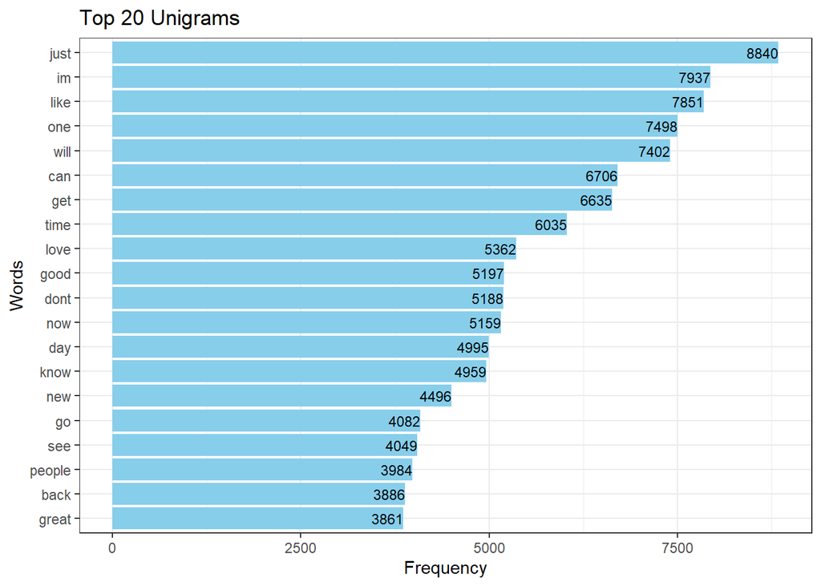

```r
unigram.plot
```

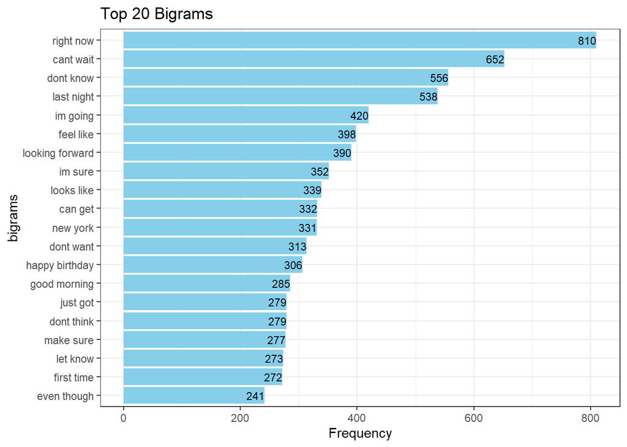

```r
bigram.plot
```

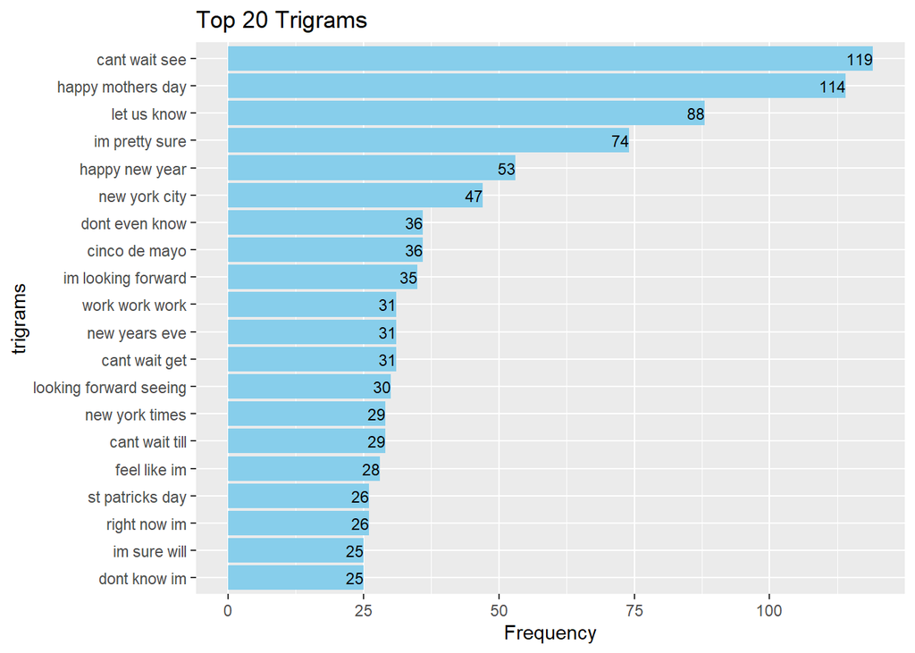

```r
trigram.plot
```

We can present similar information as word clouds as well.

[figure not shown]

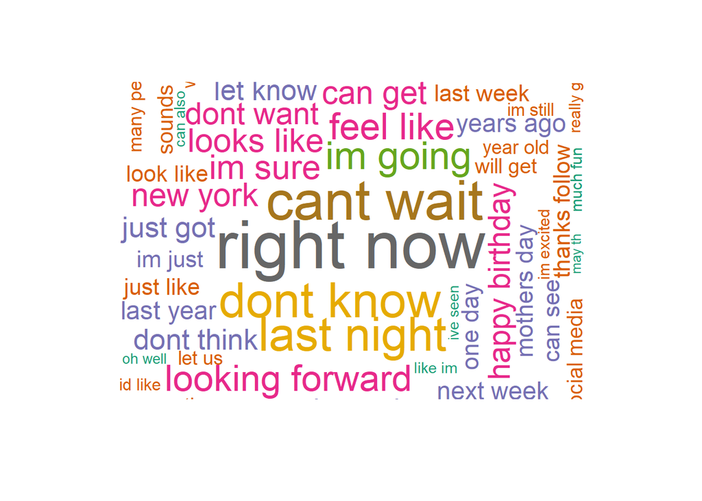

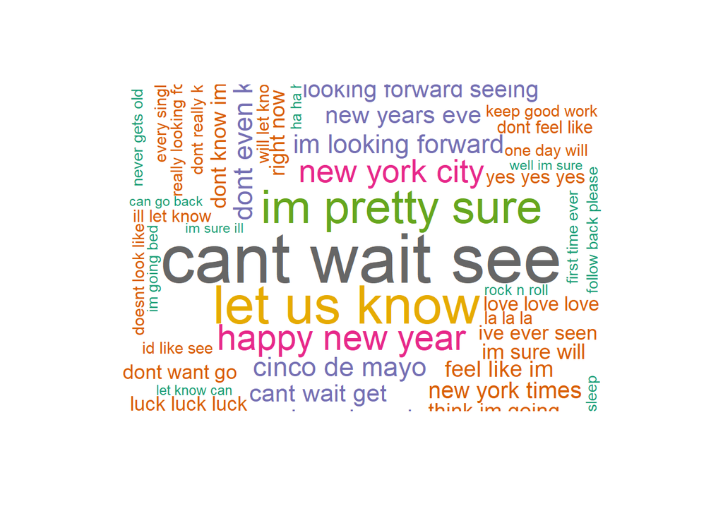

Next we will analyze how many unique words are needed to cover 50% and 90% cumulative frequency of the sample and plot it.

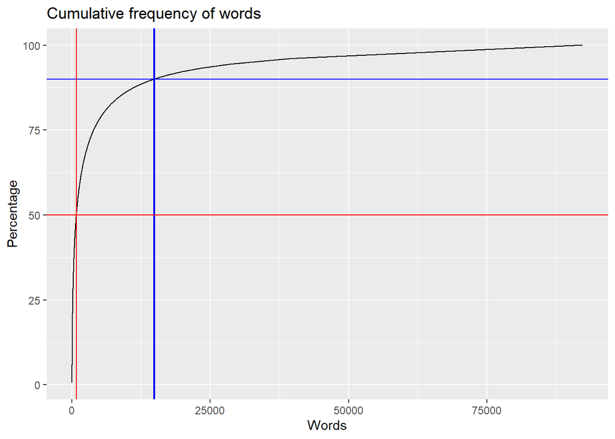

```r
cumsum.plot
```

```r
freq50
```

```
##    Words Percentage
## 1:   783     49.955
## 2:   784     49.975
## 3:   785     49.995
## 4:   786     50.016
## 5:   787     50.036
```

```r
freq90
```

```
##      Words Percentage
##   1: 14783     89.950
##   2: 14784     89.950
##   3: 14785     89.951
##   4: 14786     89.951
##   5: 14787     89.952
##  ---
## 187: 14969     90.048
## 188: 14970     90.048
## 189: 14971     90.049
## 190: 14972     90.049
## 191: 14973     90.050
```

## Next steps

The next steps would be to:

1. Study possible algorithms for the next word prediction
2. Decide how many ngrams to use
3. Balance between prediction accuracy and speed/performance
4. Design the Shiny app